# carlos_hernandez_project_05

1. Project Information
2. Imports
3. The Data
4. EDA: Discover & Visualize the Data
5. Prepare the Data
6. Modeling  
   6.1 Models to Evaluate  
   6.2 Split the Data - Train, Test, Validation Sets  
   6.3 K-Means Clustering  
   6.4 Hierarchial Clustering - Agglomerative  
   6.5 Measure & Compare Models' Performance
7. Results & Conclusions

# 1. Project Information

Back to Table of Contents

### Objective

To identify different segments in the existing customer based on their spending patterns as well as past interaction with the bank.

### Background

AllLife Bank wants to focus on its credit card customer base in the next financial year. They have been advised by their marketing research team, that the penetration in the market can be improved. Based on this input, the Marketing team proposes to run personalised campaigns to target new customers as well as upsell to existing customers. Another insight from the market research was that the customers perceive the support services of the back poorly. Based on this, the Operations team wants to upgrade the service delivery model, to ensure that customers queries are resolved faster. Head of Marketing and Head of Delivery both decide to reach out to the Data Science team for help.

### Key Questions

1. How many different segments of customers are there?
2. How are these segments different from each other?
3. What are your recommendations to the bank on how to better market to and service these customers?

### Data Provided

Data is of various customers of a bank with their credit limit, the total number of credit cards the customer has, and different channels through which customer has contacted the bank for any queries, different channels include visiting the bank, online and through a call centre.

### Problem Frame

Building a model is probably not the end goal.

1. Current Solution to problem:
2. Reliability of current solution (i.e. margin of error, consistency):
3. Sustainability of current solution (i.e. update frequency workflow):

#### Modeling

1. Supervised vs Unsupervised vs Reiforcement? None of these (clustering)
2. Regression - No
3. Batch (*non-continuous flow of data, can fit in memory*) vs Oline (*continuous flow of data*): Batch
4. Instance-Based vs Model-Based Learning?
5. Input(s): Single vs Multiple - Multiple
6. Output(s): Single (Univariate Regression) vs Multiple Values (Multivariate Regression) - single
7. Performance Measure(s) - RMSE vs MAE? Neither

# 2. Imports

Back to Table of Contents

Import libraries and settings

```python
import warnings
warnings.filterwarnings('ignore')

import numpy as np
import pandas as pd
from pandas_profiling import ProfileReport
import pydotplus as pydot
import seaborn as sns
from matplotlib import pyplot as plt
%matplotlib inline
sns.set(color_codes=True)

from scipy.stats import randint as sp_randint
from scipy.stats import zscore
import sklearn
from sklearn.model_selection import train_test_split
from sklearn.cluster import KMeans, AgglomerativeClustering
from sklearn.decomposition import PCA
from scipy.cluster.hierarchy import cophenet, dendrogram, linkage
from scipy.spatial.distance import pdist #Pairwise distribution between data points
from sklearn.model_selection import cross_val_score, cross_val_predict, train_test_split
from sklearn.preprocessing import RobustScaler, StandardScaler, MinMaxScaler
from sklearn import metrics
from sklearn.metrics import silhouette_score, accuracy_score,f1_score,recall_score,precision_score, confusion_matrix, mean_squared_error #-----model validation scores
from sklearn.feature_extraction.text import CountVectorizer  #DT does not take strings as input for the model fit step

from yellowbrick.classifier import ClassificationReport, ROCAUC

import missingno as msno_plot #--------------plotting missing values
from os import system

from IPython.display import display #---------------------for displaying multiple data frames in one output
from IPython.core.display import display, HTML
display(HTML("<style>.container { width:95% !important; }</style>"))
plt.style.use('ggplot')
pd.options.display.float_format = '{:,.4f}'.format

import ipywidgets as widgets
from ipywidgets import interactive
from IPython.display import clear_output
```

# 3. The Data

Back to Table of Contents

```python
#dataset = "./examples"
data = "CreditCardCustomerData.csv"
```

```python
df = pd.read_csv(data)
```

```python
profile = ProfileReport(df, title='Pandas Profiling Report', explorative=True)
```

```python
profile.to_widgets()
```

# 4. Discover & Visualize the Data

Back to Table of Contents

## 4.1 General Data Information

**Tasks Executed in this section**

1. Shape
2. Column Names (Attributes)
3. Info (Counts / Types)
4. Missing Values
5. Unique Values
6. Duplicate Records (Drop Unique ID Varibles if needed)
7. Head & Tail (first 5 / last 5 rows of data)

**Findings**

**Actions**

1. Dropped unique Record ID column ('Sl_No')
2. Dropped Customer ID colum ('Customer Key')

### Shape

```python
print(df.shape)
```

```
(660, 7)
```

### Column Names (attributes)

```python
print(df.columns)
```

```
Index(['Sl_No', 'Customer Key', 'Avg_Credit_Limit', 'Total_Credit_Cards',
       'Total_visits_bank', 'Total_visits_online', 'Total_calls_made'],
      dtype='object')
```

### Info (Counts / Types)

```python
print(df.info())
print()
print(df.size)
```

```
<class 'pandas.core.frame.DataFrame'>
RangeIndex: 660 entries, 0 to 659
Data columns (total 7 columns):
 #   Column               Non-Null Count  Dtype
---  ------               --------------  -----
 0   Sl_No                660 non-null    int64
 1   Customer Key         660 non-null    int64
 2   Avg_Credit_Limit     660 non-null    int64
 3   Total_Credit_Cards   660 non-null    int64
 4   Total_visits_bank    660 non-null    int64
 5   Total_visits_online  660 non-null    int64
 6   Total_calls_made     660 non-null    int64
dtypes: int64(7)
memory usage: 36.2 KB
None

4620
```

### Unique Values

```python
df.nunique()
```

```
Sl_No                  660
Customer Key           655
Avg_Credit_Limit       110
Total_Credit_Cards      10
Total_visits_bank        6
Total_visits_online     16
Total_calls_made        11
dtype: int64
```

### Drop Unique ID Variables

```python
df=df.drop(['Sl_No','Customer Key'], axis=1)
df.columns
```

```
Index(['Avg_Credit_Limit', 'Total_Credit_Cards', 'Total_visits_bank',
       'Total_visits_online', 'Total_calls_made'],
      dtype='object')
```

### Deduplicate Records

```python
dupes = df.duplicated()
sum(dupes)
```

```
11
```

```python
print(df.info())
df=df.drop_duplicates()
print()
print(df.info())
dupes = df.duplicated()
print()
sum(dupes)
```

```
<class 'pandas.core.frame.DataFrame'>
RangeIndex: 660 entries, 0 to 659
Data columns (total 5 columns):
 #   Column               Non-Null Count  Dtype
---  ------               --------------  -----
 0   Avg_Credit_Limit     660 non-null    int64
 1   Total_Credit_Cards   660 non-null    int64
 2   Total_visits_bank    660 non-null    int64
 3   Total_visits_online  660 non-null    int64
 4   Total_calls_made     660 non-null    int64
dtypes: int64(5)
memory usage: 25.9 KB
None

<class 'pandas.core.frame.DataFrame'>
Int64Index: 649 entries, 0 to 659
Data columns (total 5 columns):
 #   Column               Non-Null Count  Dtype
---  ------               --------------  -----
 0   Avg_Credit_Limit     649 non-null    int64
 1   Total_Credit_Cards   649 non-null    int64
 2   Total_visits_bank    649 non-null    int64
 3   Total_visits_online  649 non-null    int64
 4   Total_calls_made     649 non-null    int64
dtypes: int64(5)
memory usage: 30.4 KB
None
```

```
0
```

### Missing Values

```python
df.isna().sum()
```

```
Avg_Credit_Limit       0
Total_Credit_Cards     0
Total_visits_bank      0
Total_visits_online    0
Total_calls_made       0
dtype: int64
```

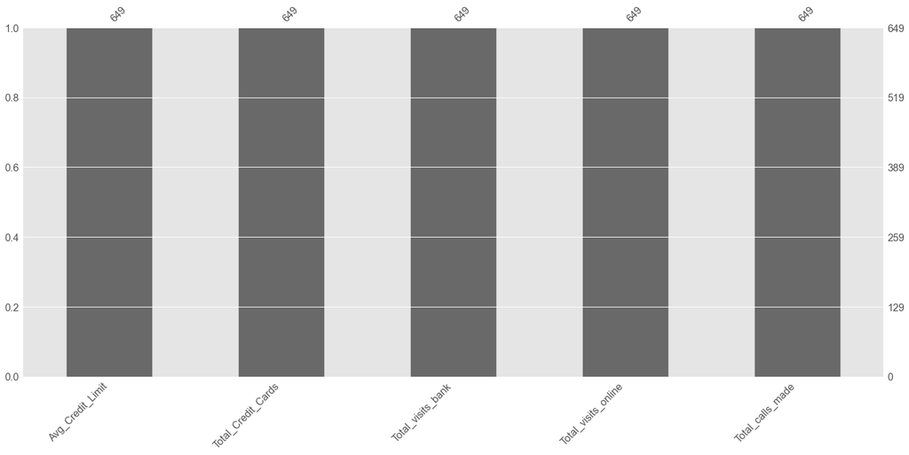

```python
msno_plot.bar(df);
```

### Unique Values

```python
df.nunique()
```

```
Avg_Credit_Limit       110
Total_Credit_Cards      10
Total_visits_bank        6
Total_visits_online     16
Total_calls_made        11
dtype: int64
```

```python
uniqueValues = df.columns.unique()
print(uniqueValues)
```

```
Index(['Avg_Credit_Limit', 'Total_Credit_Cards', 'Total_visits_bank',
       'Total_visits_online', 'Total_calls_made'],
      dtype='object')
```

### Head & Tail (first 5 / last 5 rows of data)

```python
pd.concat([df.head(5),df.tail(5)])
```

|  | Avg_Credit_Limit | Total_Credit_Cards | Total_visits_bank | Total_visits_online | Total_calls_made |
| --- | --- | --- | --- | --- | --- |
| 0 | 100000 | 2 | 1 | 1 | 0 |
| 1 | 50000 | 3 | 0 | 10 | 9 |
| 2 | 50000 | 7 | 1 | 3 | 4 |
| 3 | 30000 | 5 | 1 | 1 | 4 |
| 4 | 100000 | 6 | 0 | 12 | 3 |
| 655 | 99000 | 10 | 1 | 10 | 0 |
| 656 | 84000 | 10 | 1 | 13 | 2 |
| 657 | 145000 | 8 | 1 | 9 | 1 |
| 658 | 172000 | 10 | 1 | 15 | 0 |
| 659 | 167000 | 9 | 0 | 12 | 2 |

### Restructure Dataframe Attributes

**Tasks Executed in this section**

1. Separate Numeric from Categorical Attributes
2. Reorder Attributes to Place Object Types on "Right of Dataframe"
3. Separate Predictor(s) from Target(s)

**Findings**

1. All attributes are numeric

**Actions**

#### Separate Numeric from Categorical Attributes

```python
num_cols=[]
cat_cols=[]

for i in df.columns:
    if df[i].dtypes!=object:
        num_cols.append(i)
    else:
        cat_cols.append(i)

if len(df.columns) == len(num_cols):
    print("all columns are numeric")
else:
    print("number of numeric columns: ",len(num_cols))
    print("the numeric columns are: ", num_cols)
    print("number of categorical columns: ",len(cat_cols))
    print("the categorical columns are: ", cat_cols)
```

```
all columns are numeric
```

#### Reorder Attributes to Place Object Types on "Right of Dataframe"

```python
if len(df.columns) == len(num_cols):
    df = df[num_cols]
else:
    df = df[num_cols].append(df[cat_cols])

pd.concat([df.head(5),df.tail(5)])
#print(df.info())
```

|  | Avg_Credit_Limit | Total_Credit_Cards | Total_visits_bank | Total_visits_online | Total_calls_made |
| --- | --- | --- | --- | --- | --- |
| 0 | 100000 | 2 | 1 | 1 | 0 |
| 1 | 50000 | 3 | 0 | 10 | 9 |
| 2 | 50000 | 7 | 1 | 3 | 4 |
| 3 | 30000 | 5 | 1 | 1 | 4 |
| 4 | 100000 | 6 | 0 | 12 | 3 |
| 655 | 99000 | 10 | 1 | 10 | 0 |
| 656 | 84000 | 10 | 1 | 13 | 2 |
| 657 | 145000 | 8 | 1 | 9 | 1 |
| 658 | 172000 | 10 | 1 | 15 | 0 |
| 659 | 167000 | 9 | 0 | 12 | 2 |

#### Separate Predictor(s) from Target(s)

Not required for the problem at hand

```python
#targets[] = df['strength']
#predictors[] = df.drop(targets)
```

## 4.2 Univariate & Multivariate Analysis

**Tasks Executed in this section**

1. Univariate Analysis
2. Multivariate Analysis

**Findings**

1. Univariate Analysis
2. Multivariate Analysis

**Actions**

### Univariate Analysis

**Tasks Executed in this section**

1. Descriptive Statistics
2. Histograms
3. Boxplots

**Findings**

1. Highly Skewed Distributions ('Avg_Credit_Limit', 'Total_visits_online')
2. Outliers present ('Avg_Credit_Limit', 'Total_visits_online')

**Actions**

1. Normalize to remove skewness
2. Remove Outliers

#### Descriptive Statistics

```python
df.describe().transpose()
```

|  | count | mean | std | min | 25% | 50% | 75% | max |
| --- | --- | --- | --- | --- | --- | --- | --- | --- |
| Avg_Credit_Limit | 649.0000 | 34,878.2743 | 37,813.7366 | 3,000.0000 | 11,000.0000 | 18,000.0000 | 49,000.0000 | 200,000.0000 |
| Total_Credit_Cards | 649.0000 | 4.7088 | 2.1738 | 1.0000 | 3.0000 | 5.0000 | 6.0000 | 10.0000 |
| Total_visits_bank | 649.0000 | 2.3975 | 1.6251 | 0.0000 | 1.0000 | 2.0000 | 4.0000 | 5.0000 |
| Total_visits_online | 649.0000 | 2.6240 | 2.9529 | 0.0000 | 1.0000 | 2.0000 | 4.0000 | 15.0000 |
| Total_calls_made | 649.0000 | 3.5901 | 2.8779 | 0.0000 | 1.0000 | 3.0000 | 5.0000 | 10.0000 |

#### Histograms

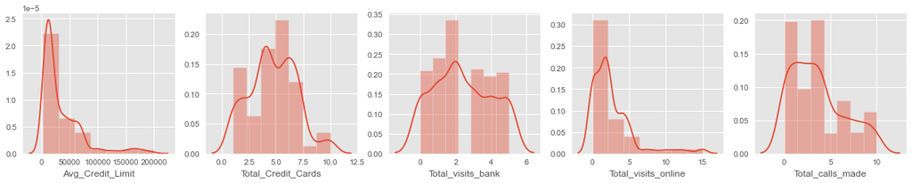

```python
# distributions of numerical (continuous) attributes
col_num = df[num_cols]
bins=7
plt.figure(figsize= (20,15))  # setting the figure size
pos = 1  # we will use this variable to index each of the plots
j=1
for i in col_num:
    plt.subplot(4, 5, pos)
    sns.distplot(df[i], bins=bins)
    pos += 1
```

```python
for i in col_num:
    value = df[i].value_counts(normalize=True).sort_index().round(2)
    print("for ", i)
    print(value)
    print()
```

```
for  Avg_Credit_Limit
3000     0.0000
5000     0.0300
6000     0.0500
7000     0.0400
8000     0.0500
          ...
184000   0.0000
186000   0.0000
187000   0.0000
195000   0.0000
200000   0.0000
Name: Avg_Credit_Limit, Length: 110, dtype: float64

for  Total_Credit_Cards
```

[output cut: 53 more lines]

#### Boxplots

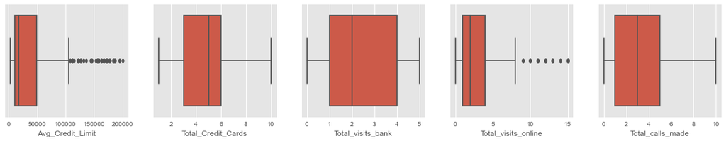

```python
col_num = df[num_cols]
plt.figure(figsize=(20,15))
pos = 1
for i in col_num:
    plt.subplot(4, 5, pos)
    sns.boxplot(df[i])
    pos += 1
```

### Multivariate Analysis

**Tasks Executed in this section**

1. Predictors
2. Predictor(s) vs Target(s)
3. Collinearity / Correlations

**Findings**

**Actions**

```python
opts = df.columns.values
selector = widgets.SelectMultiple(options=opts, value=[opts[1]], rows=len(opts), description='Variables', disabled=False)

output = widgets.Output()
display(selector)
display(output)

def multiplot(widg):
    choices = widg['new']
    data = df.loc[:, choices] if choices else df
    output.clear_output(wait=True)
    with output:
        ax = data.plot()
        plt.show()
selector.observe(multiplot, names='value')
```

**On Radial Visualization aka RadViz (chart below)**

1. RadViz is a multivariate data visualization algorithm that plots each feature dimension uniformly around the circumference of a circle.
2. It then plots points on the interior of the circle such that the point normalizes its values on the axes from the center to each arc.
3. This mechanism allows as many dimensions as will easily fit on a circle, greatly expanding the dimensionality of the visualization.
4. Data scientists use this method to detect separability between classes. E.g. is there an opportunity to learn from the feature set or is there just too much noise?
5. RadViz allow to project a N-dimensional data set into a 2D space where the influence of each dimension can be interpreted as a balance between the influence of all dimensions.
6. Each Series in the DataFrame is represented as a evenly distributed slice on a circle.
7. Each data point is rendered in the circle according to the value on each Series.
8. Highly correlated Series in the DataFrame are placed closer on the unit circle.

From: https://www.scikit-yb.org/en/latest/api/features/radviz , https://pandas.pydata.org/docs/reference/api/pandas.plotting.radviz

```python
from pandas.plotting import radviz
opts2 = df.columns.values
dfrv=df.iloc[:, :-1]
selector2 = widgets.RadioButtons(options=opts2, description='Select Target:', disabled=False)

output2 = widgets.Output()
display(selector2)
display(output2)

def radplot(widg):
    choices = widg['new']
    data = df.loc[:, choices] if choices else df
    output2.clear_output(wait=True)
    with output2:
        fig, ax = plt.subplots(figsize=(13, 6))
        dfrv['target_bins']= pd.cut(df[selector2.value], 11)
        ax = radviz(dfrv, "target_bins", colormap="bwr")
        plt.show()

selector2.observe(radplot,names = 'value')
```

**Notes**

1. weakest relationships with target among predictors - there is no clear "weakest relationship" to Avg_Credit_Limit"
2. strongest relationships with target among predictors - there is no clear "strongest relationship" to Avg_Credit_Limit"

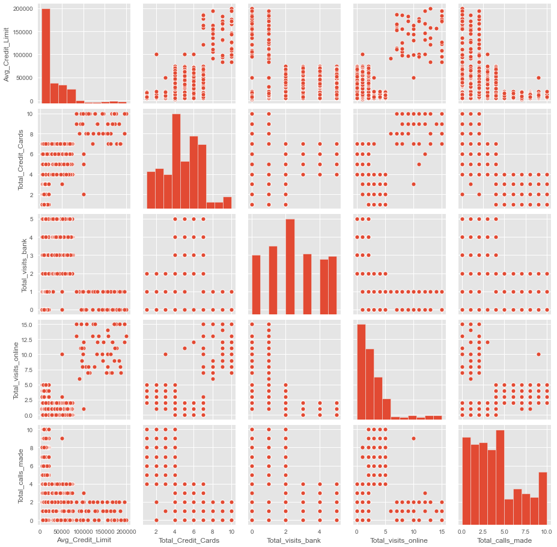

```python
sns.pairplot(df)
```

```python
opts4 = df.columns.values
selector4 = widgets.RadioButtons(options=opts4, description='Select Hue Attribute:', disabled=False)

output4 = widgets.Output()
display(selector4)
display(output4)

def pairplot3(widg):
    choices = widg['new']
    data = df.loc[:, choices] if choices else df
    output4.clear_output(wait=True)
    with output4:
        df['hue_bins']= pd.cut(df[selector4.value], 3)
        ax = sns.pairplot(df, hue = "hue_bins",  palette="husl")
        plt.show()
selector4.observe(pairplot3,names = 'value')
```

Note: No variables appear to be strongly correlated

#### Correlations / Collinearity

```python
df.corr() # It will show correlation of only numerical variables here.
```

|  | Avg_Credit_Limit | Total_Credit_Cards | Total_visits_bank | Total_visits_online | Total_calls_made |
| --- | --- | --- | --- | --- | --- |
| Avg_Credit_Limit | 1.0000 | 0.6126 | -0.0992 | 0.5529 | -0.4184 |
| Total_Credit_Cards | 0.6126 | 1.0000 | 0.3115 | 0.1700 | -0.6533 |
| Total_visits_bank | -0.0992 | 0.3115 | 1.0000 | -0.5541 | -0.5043 |
| Total_visits_online | 0.5529 | 0.1700 | -0.5541 | 1.0000 | 0.1255 |
| Total_calls_made | -0.4184 | -0.6533 | -0.5043 | 0.1255 | 1.0000 |

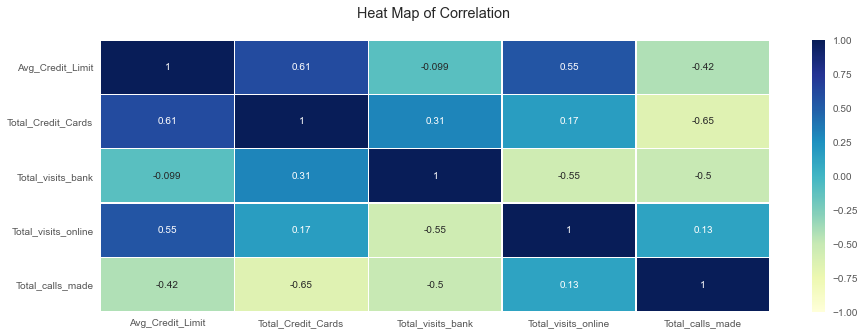

```python
corr = df.corr();
fig, ax = plt.subplots()
fig.set_size_inches(15, 5)
plt.title('Heat Map of Correlation \n')
sns.heatmap(corr,annot=True,cmap='YlGnBu',vmin=-1,vmax=1, linewidths=.5, center=0);
```

**Notes**

1. strongest negative correlation(s): Total_Credit_Cards/Total_calls_made (-.65)
2. strongest positive correlations(s): Avg_Credit_Limit / Total Credit_Cards (.62)
3. strongest negative correlation(s) beteen predictors and target: Total_Calls_made (-.42)
4. strongest positive correlation(s) beteen predictors and target: Total_Credit_Cards (.61)

No correlation (positive or negative) is strong enough to require removal from data set

# 5. Prepare the Data for Machine Learning Algorithms

Back to Table of Contents

**Tasks Executed in this section**

1. Data Cleaning
2. Feature Selection
3. Feature Scaling
4. Dimensionality Reduction

**Findings**

**Actions**

1. Normalize Data

## 5.1 Data Cleaning

### Handle Text & Categorical Data

Unnecessary as all attributes are numerical. (Custom Transformers?)

### Treat (if necessary) - Missing Values and/or Zeros

1. No missing data.
2. Values of Zero "OK"

No treatment necessary.

### Treat (if necessary) - Erronenous and/or Unique Values and/or Outliers

1. Cannot determine "erroneous" values without SME.
2. Outliers removed via Winsorization

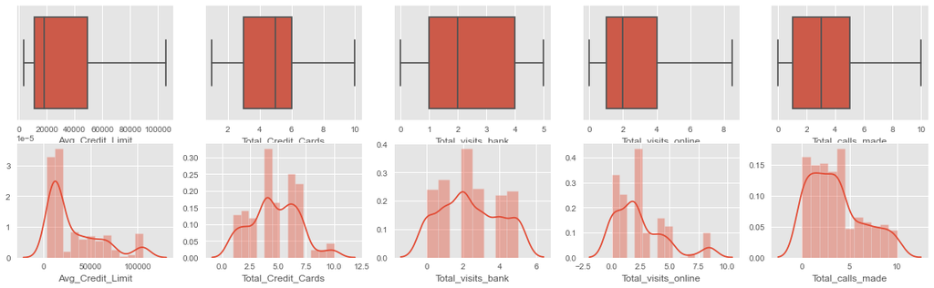

```python
# remove outliers
for i in col_num:
    q1, q2, q3 = df[i].quantile([0.25,0.5,0.75])
    IQR = q3 - q1
    lower_cap=q1-1.5*IQR
    upper_cap=q3+1.5*IQR
    df[i]=df[i].apply(lambda x: upper_cap if x>(upper_cap) else (lower_cap if x<(lower_cap) else x))

# confirm outliers were removed
plt.figure(figsize=(20,15))
pos = 1

for i in col_num:
    plt.subplot(5, 5, pos)
    sns.boxplot(df[i])
    pos += 1

for i in col_num:
    plt.subplot(5, 5, pos)
    sns.distplot(df[i])
    pos += 1
```

### Data Post-Cleaning

```python
df.describe().transpose()
```

|  | count | mean | std | min | 25% | 50% | 75% | max |
| --- | --- | --- | --- | --- | --- | --- | --- | --- |
| Avg_Credit_Limit | 649.0000 | 31,981.5100 | 28,759.1043 | 3,000.0000 | 11,000.0000 | 18,000.0000 | 49,000.0000 | 106,000.0000 |
| Total_Credit_Cards | 649.0000 | 4.7088 | 2.1738 | 1.0000 | 3.0000 | 5.0000 | 6.0000 | 10.0000 |
| Total_visits_bank | 649.0000 | 2.3975 | 1.6251 | 0.0000 | 1.0000 | 2.0000 | 4.0000 | 5.0000 |
| Total_visits_online | 649.0000 | 2.4122 | 2.2676 | 0.0000 | 1.0000 | 2.0000 | 4.0000 | 8.5000 |
| Total_calls_made | 649.0000 | 3.5901 | 2.8779 | 0.0000 | 1.0000 | 3.0000 | 5.0000 | 10.0000 |

```python
opts5 = df.columns.values
selector5 = widgets.RadioButtons(options=opts4, description='Select Hue Attribute:', disabled=False)

output5 = widgets.Output()
display(selector5)
display(output5)

def pairplot4(widg):
    choices = widg['new']
    data = df.loc[:, choices] if choices else df
    output5.clear_output(wait=True)
    with output5:
        df['hue_bins']= pd.cut(df[selector5.value], 3)
        ax = sns.pairplot(df, hue = "hue_bins",  palette="husl")
        plt.show()
selector5.observe(pairplot4,names = 'value')
```

## 5.2 Feature Selection

Irrelevant Features? Drop Features? No other features removed from dataset other than identifiers

## 5.3 Feature Engineering

1. Discretize continuous feature? No (SME may guide)
2. Decompose features (e.g., categorical, date/time, etc.)? Not necessary
3. Add promising transformations of features (e.g., log(x), sqrt(x), x^2, etc.)? No (SME may guide)
4. Aggregate features into promising new features? No

## 5.4 Feature Scaling

Notes/Excerpts from Aurelien Geron's "Hands On Machine Learning with SciKit Learn, Keras, and Tensorflow - 2nd Edition":

1. "One of the most important transformations you need to apply to your data is feature scaling. With few exceptions, Machine Learning algorithms don’t perform well when the input numerical attributes have very different scales."
2. "Scaling the target values is generally notrequired."
3. "There are two common ways to get all attributes to have the same scale: *min-max scaling* and *standardization*."
4. "*Min-max scaling* (many people call this *normalization*) is quite simple: values are shifted and rescaled so that they end up ranging from 0 to 1."
5. "*Standardization* is quite different: first it subtracts the mean value (so standardized values always have a zero mean), and then it divides by the standard deviation so that the resulting distribution has unit variance. Unlike min-max scaling, standardization does not bound values to a specific range, which may be a problem for some algorithms (e.g., neural networks often expect an input value ranging from 0 to 1). However, standardization is much less affected by outliers."
6. "As with all the transformations, it is important to fit the scalers to the training data only, not to the full dataset (including the test set). Only then can you use them to transform the training set and the test set (and new data)."

Notes/Excerpts from Matt Harrison's "Machine Learning Pocket Reference - Working with structured data in python":

1. Normalization wil help the performance of models that depend on a distance metric to determine similarity (not a requirement of tree models).
2. "*Standardizing* is translating the data so that it has a mean value of zero and a standard deviation of one. This way models don't treat variables with larger scales as more important than smaller scaled variables.

Standardize? Yes as required for clustering Normalize?

```python
#df_preZ = df.drop('Avg_Credit_Limit', axis=1)
df_preZ  = df
```

```python
df_z = df_preZ.apply(zscore)
pd.concat([df_z.head(5),df_preZ.tail(5)])
```

|  | Avg_Credit_Limit | Total_Credit_Cards | Total_visits_bank | Total_visits_online | Total_calls_made |
| --- | --- | --- | --- | --- | --- |
| 0 | 2.3669 | -1.2471 | -0.8606 | -0.6232 | -1.2484 |
| 1 | 0.6270 | -0.7867 | -1.4764 | 2.6868 | 1.8812 |
| 2 | 0.6270 | 1.0548 | -0.8606 | 0.2594 | 0.1425 |
| 3 | -0.0690 | 0.1341 | -0.8606 | -0.6232 | 0.1425 |
| 4 | 2.3669 | 0.5945 | -1.4764 | 2.6868 | -0.2052 |
| 655 | 99,000.0000 | 10.0000 | 1.0000 | 8.5000 | 0.0000 |
| 656 | 84,000.0000 | 10.0000 | 1.0000 | 8.5000 | 2.0000 |
| 657 | 106,000.0000 | 8.0000 | 1.0000 | 8.5000 | 1.0000 |
| 658 | 106,000.0000 | 10.0000 | 1.0000 | 8.5000 | 0.0000 |
| 659 | 106,000.0000 | 9.0000 | 0.0000 | 8.5000 | 2.0000 |

```python
sc = StandardScaler()
X_std = pd.DataFrame(sc.fit_transform(df_preZ),columns=df_preZ.columns)
pd.concat([df_z.head(5),X_std.tail(5)]).style.background_gradient(cmap='RdBu',axis=1)
```

|  | Avg_Credit_Limit | Total_Credit_Cards | Total_visits_bank | Total_visits_online | Total_calls_made |
| --- | --- | --- | --- | --- | --- |
| 0 | 2.366936 | -1.247087 | -0.860606 | -0.623244 | -1.248443 |
| 1 | 0.627015 | -0.786701 | -1.476410 | 2.686783 | 1.881237 |
| 2 | 0.627015 | 1.054846 | -0.860606 | 0.259430 | 0.142526 |
| 3 | -0.068953 | 0.134072 | -0.860606 | -0.623244 | 0.142526 |
| 4 | 2.366936 | 0.594459 | -1.476410 | 2.686783 | -0.205216 |
| 644 | 2.332137 | 2.436005 | -0.860606 | 2.686783 | -1.248443 |
| 645 | 1.810161 | 2.436005 | -0.860606 | 2.686783 | -0.552958 |
| 646 | 2.575726 | 1.515232 | -0.860606 | 2.686783 | -0.900701 |
| 647 | 2.575726 | 2.436005 | -0.860606 | 2.686783 | -1.248443 |
| 648 | 2.575726 | 1.975619 | -1.476410 | 2.686783 | -0.552958 |

# 6. Modeling

Back to Table of Contents

**Applicable Models**

1. K-Means Clustering
2. Hierarchial Clustering - Agglomerative

## 6.1 List Models to Evaluate

Back to Table of Contents

**Models of interest**

1. K-Means Clustering
2. Hierarchial Clustering - Agglomerative
3. Hierarchial Clustering - Divisive

## 6.2 Split the Data - Train, Test, Validation Sets

Back to Table of Contents

not necessary for clustering

```python
# Split X and y into training and test set in 70:30 ratio
#x2_train, x2_test, y2_train, y2_test = train_test_split(x2, y2, test_size=0.30, random_state=1)
```

```python
y = df['Avg_Credit_Limit']
X = df.drop(columns='Avg_Credit_Limit')
```

## 6.3 K-Means

Back to Table of Contents

Train many quick and dirty models from different categories (e.g., linear, naïve Bayes, SVM, Random Forests, neural net, etc.) using standard parameters.

```python
# List to store cluster and intra cluster distance
clusters = []
inertia_vals = []
# Since creating one cluster is similar to observing the data as a whole, multiple values of K are
# utilized to come up with the optimum cluster value
# Note: Cluster number and intra cluster distance is appended for plotting the elbow curve

for k in range(1, 10, 1):

    # train clustering with the specified K
    model = KMeans(n_clusters=k, random_state=7, n_jobs=10)
    model.fit(df_z)

    # append model to cluster list
    clusters.append(model)
    inertia_vals.append(model.inertia_)
```

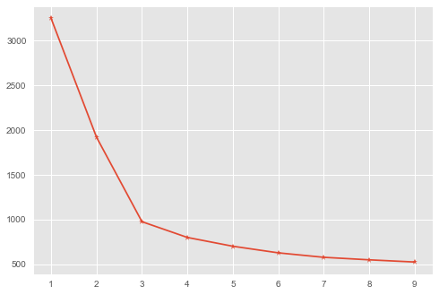

```python
# plot the inertia vs K values
plt.plot(range(1,10,1),inertia_vals,marker='*')
plt.show()
```

elbow at k=3 (optimum number of clusters)

```python
kclusters = 3
```

```python
for i in range(2,9,1):
    print("---------------------------------------")
    print(clusters[i])
    print("kmeans_silhouette_score_for_",i,"_clusters:",silhouette_score(df_z, clusters[i].predict(df_z)))
```

```
---------------------------------------
KMeans(n_clusters=3, n_jobs=10, random_state=7)
kmeans_silhouette_score_for_ 2 _clusters: 0.5180797381243987
---------------------------------------
KMeans(n_clusters=4, n_jobs=10, random_state=7)
kmeans_silhouette_score_for_ 3 _clusters: 0.37986496617829596
---------------------------------------
KMeans(n_clusters=5, n_jobs=10, random_state=7)
kmeans_silhouette_score_for_ 4 _clusters: 0.3546140293878957
---------------------------------------
KMeans(n_clusters=6, n_jobs=10, random_state=7)
kmeans_silhouette_score_for_ 5 _clusters: 0.27397240313466753
---------------------------------------
KMeans(n_clusters=7, n_jobs=10, random_state=7)
kmeans_silhouette_score_for_ 6 _clusters: 0.2674320544453248
---------------------------------------
KMeans(n_jobs=10, random_state=7)
kmeans_silhouette_score_for_ 7 _clusters: 0.25828359741752016
---------------------------------------
KMeans(n_clusters=9, n_jobs=10, random_state=7)
kmeans_silhouette_score_for_ 8 _clusters: 0.24680290638388966
```

```python
kmeans = KMeans(n_clusters=kclusters, n_init = 15, random_state=2345)
```

```python
kmeans.fit(df_z)
```

```
KMeans(n_clusters=3, n_init=15, random_state=2345)
```

```python
centroids = kmeans.cluster_centers_
```

```python
centroids
```

```
array([[ 0.07272586,  0.37279143,  0.66912713, -0.63141679, -0.55571829],
       [-0.6869796 , -1.05751613, -0.89404374,  0.50406239,  1.14798905],
       [ 2.48664235,  1.85591807, -1.10692778,  2.54555516, -0.87288132]])
```

```python
#Clculate the centroids for the columns to profile
centroid_df = pd.DataFrame(centroids, columns = list(df_z))
```

```python
print(centroid_df)
```

```
   Avg_Credit_Limit  Total_Credit_Cards  Total_visits_bank  \
0            0.0727              0.3728             0.6691
1           -0.6870             -1.0575            -0.8940
2            2.4866              1.8559            -1.1069

   Total_visits_online  Total_calls_made
0              -0.6314           -0.5557
1               0.5041            1.1480
2               2.5456           -0.8729
```

```
array([[<AxesSubplot:xlabel='k'>, <AxesSubplot:xlabel='k'>],
       [<AxesSubplot:xlabel='k'>, <AxesSubplot:xlabel='k'>]], dtype=object)
```

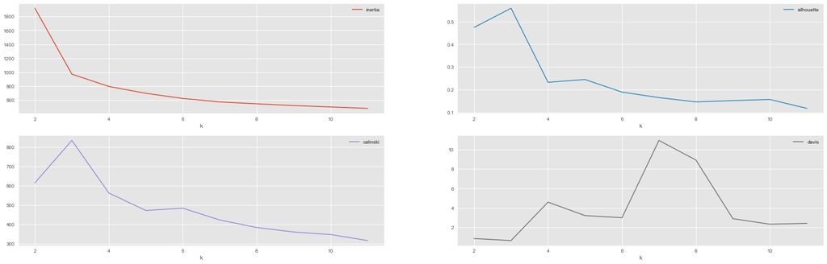

```python
inertias = []
sils = []
chs = []
dbs = []
sizes = range(2, 12)
for k in sizes:
    k2 = KMeans(random_state=42, n_clusters=k)
    k2.fit(X_std)
    inertias.append(k2.inertia_)
    sils.append(
        metrics.silhouette_score(X, k2.labels_)
    )
    chs.append(
        metrics.calinski_harabasz_score(
            X, k2.labels_
        )
    )
    dbs.append(
        metrics.davies_bouldin_score(
            X, k2.labels_
        )
    )
fig, ax = plt.subplots(figsize=(29, 9))
(
    pd.DataFrame(
        {
            "inertia": inertias,
            "silhouette": sils,
            "calinski": chs,
            "davis": dbs,
            "k": sizes,
        }
    )
    .set_index("k")
    .plot(ax=ax, subplots=True, layout=(2, 2))
)
```

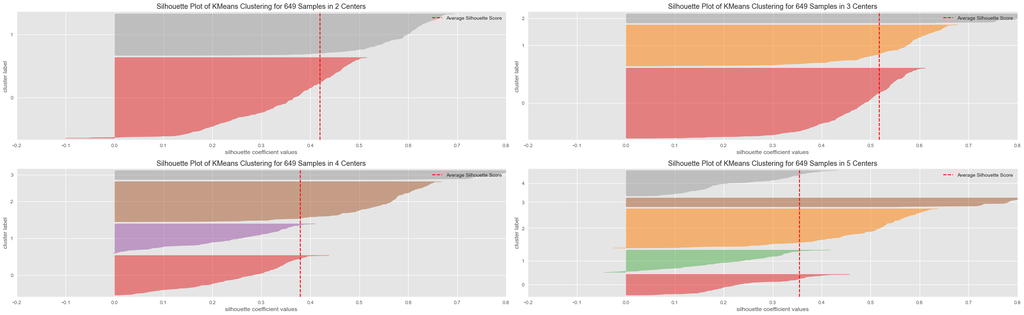

```python
from yellowbrick.cluster.silhouette import (SilhouetteVisualizer,)
fig, axes = plt.subplots(2, 2, figsize=(29, 9))
axes = axes.reshape(4)
for i, k in enumerate(range(2, 6)):
    ax = axes[i]
    sil = SilhouetteVisualizer(
        KMeans(n_clusters=k, random_state=42),
        ax=ax,
    )
    sil.fit(X_std)
    sil.finalize()
    ax.set_xlim(-0.2, 0.8)
plt.tight_layout()
```

```python
km = KMeans(n_clusters=kclusters)
km.fit(X_std)
labels = km.predict(X_std)
(
    X.assign(cluster=labels, survived=y)
    .groupby("cluster")
    .agg(["mean", "var"])
    .T
)
```

|  | cluster | 0 | 1 | 2 |
| --- | --- | --- | --- | --- |
| Total_Credit_Cards | mean | 2.4118 | 5.5185 | 8.7400 |
|  | var | 1.2070 | 1.3007 | 1.6249 |
| Total_visits_bank | mean | 0.9457 | 3.4841 | 0.6000 |
|  | var | 0.6425 | 1.2849 | 0.2449 |
| Total_visits_online | mean | 3.5543 | 0.9815 | 8.1800 |
|  | var | 1.4152 | 0.7344 | 0.3751 |
| Total_calls_made | mean | 6.8914 | 1.9921 | 1.0800 |
|  | var | 3.9609 | 2.0397 | 0.7690 |
| survived | mean | 12,239.8190 | 34,071.4286 | 103,440.0000 |
|  | var | 27,592,225.4216 | 491,477,643.0466 | 30,537,142.8571 |

## 6.4 Hierarchial Clustering - Agglomerative

Back to Table of Contents

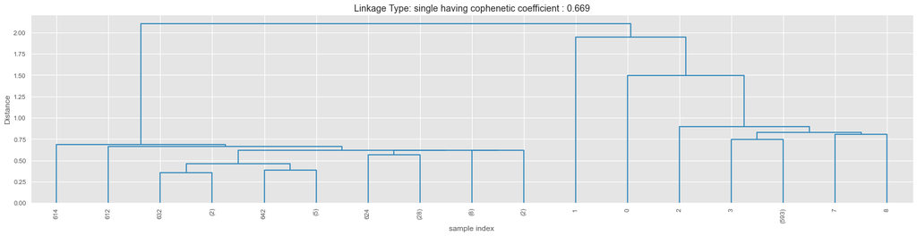

```
single 0.6687980551717484
```

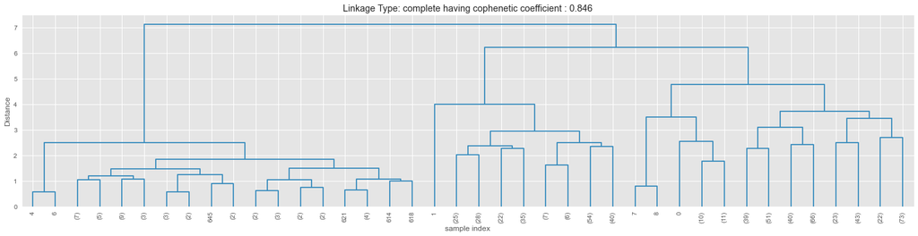

```
complete 0.8455463448314544
```

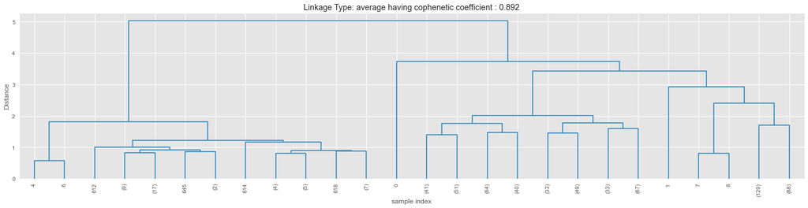

```
average 0.8922750152191901
```

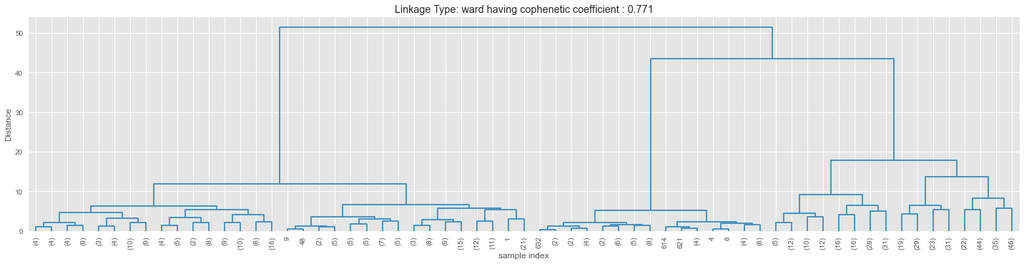

```
ward 0.7714411007322578
```

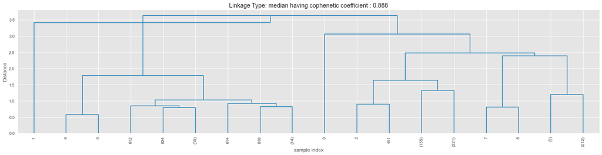

```
median 0.8878860529126427
```

```python
linkage_methods=['single','complete','average','ward','median']
results_cophenetic_coef=[]
for i in linkage_methods:
    plt.figure(figsize=(20, 5))
    plt.xlabel('sample index')
    plt.ylabel('Distance')
    Z = linkage(X_std, i)
    cc,cophn_dist=cophenet(Z,pdist(X_std))
    dendrogram(Z,leaf_rotation=90.0,p=5,leaf_font_size=10,truncate_mode='level',color_threshold=60)

    #Z - is the linkage matrix
    #leaf_rotation - Angle of leaf labels. Check how data is displayed in the x axis in the image below
    #p - No more than p levels of the dendrogram tree are displayed.
    #A “level” includes all nodes with p merges from the last merge.

    plt.tight_layout()
    plt.title("Linkage Type: "+ i +" having cophenetic coefficient : "+str(round(cc,3)) )
    plt.show()
    results_cophenetic_coef.append((i,cc))
    print (i,cc)
```

```python
results_cophenetic_coef_df=pd.DataFrame(results_cophenetic_coef,columns=['LinkageMethod','CopheneticCoefficient'])
results_cophenetic_coef_df
```

|  | LinkageMethod | CopheneticCoefficient |
| --- | --- | --- |
| 0 | single | 0.6688 |
| 1 | complete | 0.8455 |
| 2 | average | 0.8923 |
| 3 | ward | 0.7714 |
| 4 | median | 0.8879 |

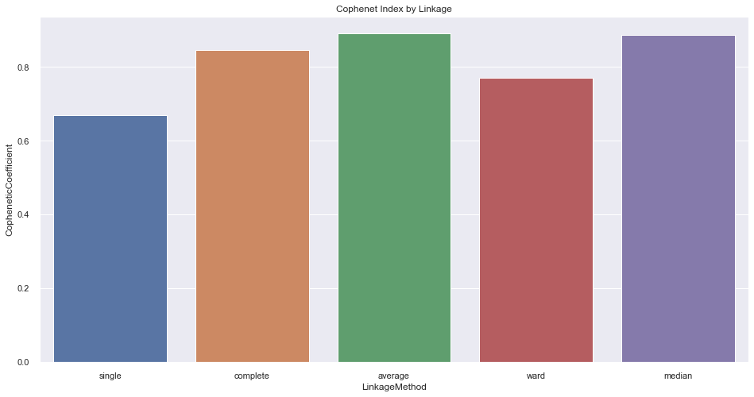

```python
# bar graph
sns.set(color_codes=True)
fig, ax = plt.subplots(figsize=(16,8)); #---Size of convas
plt.title("Cophenet Index by Linkage");
sns.barplot(results_cophenetic_coef_df['LinkageMethod'],results_cophenetic_coef_df['CopheneticCoefficient']);
```

```python
Z = linkage(X_std, metric='euclidean', method='average')
```

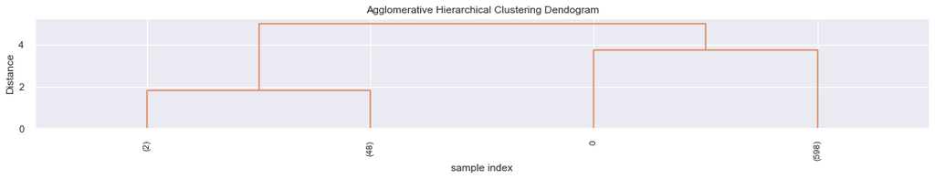

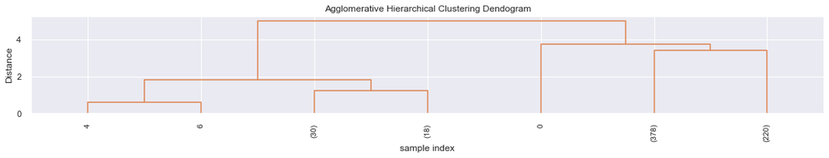

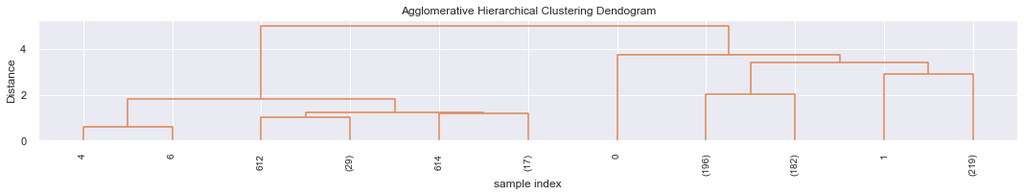

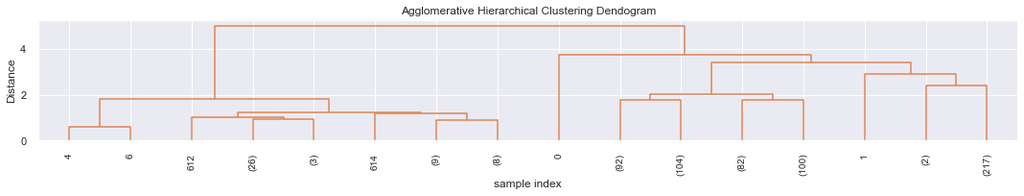

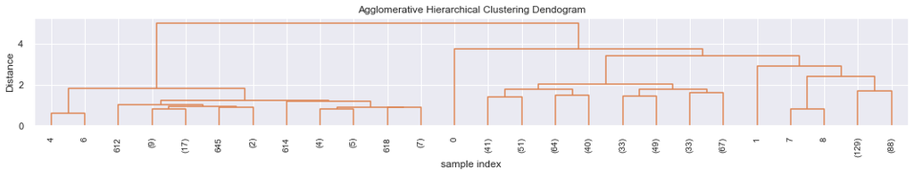

```python
for i in range(1,6):
    plt.figure(figsize=(15, 3))
    plt.title('Agglomerative Hierarchical Clustering Dendogram')
    plt.xlabel('sample index')
    plt.ylabel('Distance')
    dendrogram(Z,leaf_rotation=90.0,p=i,leaf_font_size=10,truncate_mode='level',color_threshold=60)
    plt.tight_layout()
```

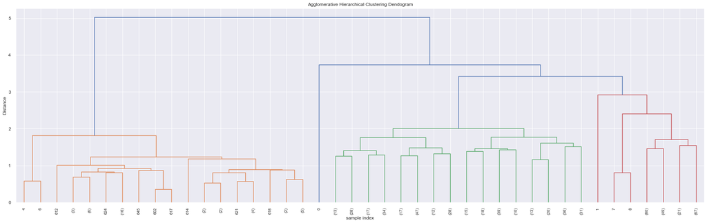

```python
plt.figure(figsize=(25, 8))
plt.title('Agglomerative Hierarchical Clustering Dendogram')
plt.xlabel('sample index')
plt.ylabel('Distance')
dendrogram(Z,leaf_rotation=90.0,p=6,leaf_font_size=10,truncate_mode='level', color_threshold=3)
plt.tight_layout()
```

```python
model = AgglomerativeClustering(n_clusters=5, affinity='euclidean',  linkage='average')
```

```python
model.fit(X_std)
```

```
AgglomerativeClustering(linkage='average', n_clusters=5)
```

```python
df['labels'] = model.labels_
df.head(10)
```

|  | Avg_Credit_Limit | Total_Credit_Cards | Total_visits_bank | Total_visits_online | Total_calls_made | labels |
| --- | --- | --- | --- | --- | --- | --- |
| 0 | 100,000.0000 | 2 | 1 | 1.0000 | 0 | 2 |
| 1 | 50,000.0000 | 3 | 0 | 8.5000 | 9 | 4 |
| 2 | 50,000.0000 | 7 | 1 | 3.0000 | 4 | 1 |
| 3 | 30,000.0000 | 5 | 1 | 1.0000 | 4 | 1 |
| 4 | 100,000.0000 | 6 | 0 | 8.5000 | 3 | 3 |
| 5 | 20,000.0000 | 3 | 0 | 1.0000 | 8 | 0 |
| 6 | 100,000.0000 | 5 | 0 | 8.5000 | 2 | 3 |
| 7 | 15,000.0000 | 3 | 0 | 1.0000 | 1 | 0 |
| 8 | 5,000.0000 | 2 | 0 | 2.0000 | 2 | 0 |
| 9 | 3,000.0000 | 4 | 0 | 1.0000 | 7 | 0 |

```python
# Calculate Avg Silhoutte Score
silhouette_hierarchical=silhouette_score(X_std, df['labels'])
print(silhouette_hierarchical)
```

```
0.44504702042235617
```

```python
for i in range(2,10):
    model = AgglomerativeClustering(n_clusters=i, affinity='euclidean',  linkage='average')
    model.fit(X_std)
    df['labels'] = model.labels_
    print("K=",i,"-",silhouette_score(X_std, df['labels']))
```

```
K= 2 - 0.5174032397031769
K= 3 - 0.3426064123440883
K= 4 - 0.48175804115275905
K= 5 - 0.44504702042235617
K= 6 - 0.3596525315745215
K= 7 - 0.27852947875104034
K= 8 - 0.25360425328556113
K= 9 - 0.2332852573946124
```

```python
model = AgglomerativeClustering(n_clusters=5, affinity='euclidean',  linkage='average')
model.fit(X_std)
```

```
AgglomerativeClustering(linkage='average', n_clusters=5)
```

Back to Table of Contents

# 7 Results & Conclusions

Back to Table of Contents

## Results

Use K-means to determine the different segments in the existing customers.